# PRIDe-RL Report

×

**PRIDe-RL Report**Analysis navigator

Application version 1.17.31

Analysis report

# Performance Ranking by Index of Deviation of Reference Limits (PRIDe-RL)

A multidimensional framework for comparative evaluation and ranking of reference-limit estimation methods

Application version 1.17.31 · Generated on 2026-10-28 15:21:26 -03

## Overview

Nominal central coverage of the equivalence interval**90%**

Standard-normal quantile (*z*)**1.64485**

Groups analyzed**2**

Methods assessed**5**

### Assessment groups

1. Group 1
2. Group 2

### Compared methods

1. TML
2. refineR
3. TMC
4. reflimR
5. LabRI

**Coverage criterion:** The equivalence interval is calculated separately around each comparative LRL and URL and defines the range within which a difference is considered not clinically relevant under the method's permissible-uncertainty criterion. Its width is based on the permissible analytical standard deviation at that RL, derived from the empirical coefficient of variation estimated from the comparative reference interval specified for each analyte. The selected 90% nominal central coverage uses *z* = 1.64485, corresponding to the 95th one-sided standard-normal percentile and the criterion proposed by Dias et al. (2027) in the paper describing the LabRI method.

## Analysis information

Information supplied for the analysis. Fields left blank are identified explicitly.

**Specialist responsible for data analysis**

Alan Carvalho Dias

**Data Source**

Group 1 (real-world data) — LDH, AMY, Ca, FT4 e TSH [1]:  
Individual-level data for lactate dehydrogenase (LDH), amylase (AMY), total calcium (Ca), free thyroxine (FT4), and thyroid-stimulating hormone (TSH) were obtained from the publicly available dataset accompanying Omuse et al. [27], deposited in Dryad (doi:10.5061/dryad.nvx0k6dns). The original study was conducted in Kenya as part of the IFCC global reference interval project, using a harmonized recruitment protocol. Participants were recruited between January and October 2015, predominantly from urban populations in Nairobi, Kiambu, Kisii, and Nakuru. Of 596 volunteers, 533 met the initial eligibility criteria, comprising 260 men and 273 women. Additional analyte-specific exclusions were applied when establishing the published reference intervals.  
Group 1 (real-world data) — ALT, GGT, Hb, LYM, PLT, RBC e WBC [2]:  
Individual-level data for alanine aminotransferase (ALT), gamma-glutamyl transferase (GGT), hemoglobin (Hb), absolute lymphocyte count (LYM), platelet count (PLT), red blood cell count (RBC), and white blood cell count (WBC) were obtained from the supplementary dataset accompanying Abbam et al. [28]. This cross-sectional study recruited apparently healthy voluntary blood donors from four eco-geographical zones in Ghana: Coastal Savannah, Rain Forest, Savannah, and Transitional. Recruitment took place between July 2019 and March 2020. Of 1,227 candidates screened, 992 were included, comprising 500 men and 492 women; biochemical results were available for 874 participants. Eligibility was assessed using a health questionnaire and laboratory screening for potentially confounding conditions, including malaria, viral infections, glucose-6-phosphate dehydrogenase deficiency, and abnormal hemoglobin variants.  
Group 2 (simulated data) [3]:  
Simulated datasets were obtained from the refineR R package [12] and comprised testcase1, testcase2, and testcase4. Each dataset contains a mixture of simulated non-pathological and pathological observations. The original testcase1 dataset includes 10,000 observations, comprising 80% non-pathological and 20% pathological values; testcase2 includes 50,000 observations, comprising 60% non-pathological and 40% pathological values; and testcase4 includes 100,000 observations, comprising 90% non-pathological and 10% pathological values.  
Each scenario was evaluated at five sample sizes: 500, 1,000, 2,000, 5,000, and 10,000 for testcase1; 500, 1,000, 5,000, 10,000, and 50,000 for testcase2; and 500, 1,000, 5,000, 10,000, and 100,000 for testcase4. Smaller datasets were obtained by reproducible random subsampling using the DataSampleR R Markdown script with a fixed seed. The largest condition in each scenario corresponded to the complete original dataset.  
[1] G. Omuse, K. Ichihara, D. Maina, M. Hoffman, E. Kagotho, A. Kanyua, J. Mwangi, C. Wambua, A. Amayo, P. Ojwang, Z. Premji, R. Erasmus, Determination of reference intervals for common chemistry and immunoassay tests for Kenyan adults based on an internationally harmonized protocol and up-to-date statistical methods, PLoS ONE 15 (2020) e0235234. https://doi.org/10.1371/journal.pone.0235234.  
[2] G. Abbam, S. Tandoh, M. Tetteh, D.A. Afrifah, M.E. Annani-Akollor, E.-W. Owiredu, C. Gyasi, C. Adu-Gyamfi, B. Sackey, A.Y. Debrah, O. Addai-Mensah, Reference intervals for selected haematological and biochemical parameters among apparently healthy adults in different eco-geographical zones in Ghana, PLoS ONE 16 (2021) e0245585. https://doi.org/10.1371/journal.pone.0245585.  
[3] M. Beck, T. Ammer, C.M. Rank, A. Schuetzenmeister, refineR: Reference Interval Estimation using Real-World Data, (2021). https://doi.org/10.32614/CRAN.package.refineR.

**Measurement Procedure and Analytical Method**

Group 1 (real-world data) — LDH, AMY, Ca, FT4 e TSH [1]:  
Measurements were performed at the PathCare reference laboratory in Cape Town, South Africa. LDH, AMY, and total Ca were measured using a Beckman Coulter AU5800 chemistry analyzer. The reported analytical methods were lactate-to-pyruvate conversion for LDH, an enzymatic assay using 2-chloro-4-nitrophenyl-α-D-maltotrioside for AMY, and an Arsenazo III dye method for total Ca. FT4 and TSH were measured by enzyme immunoassays using a Beckman Coulter DxI analyzer. A value-assigned serum panel supplied through the IFCC C-RIDL project was used to assess analytical alignment; the original study reported recalibration of the LDH reference interval [1].  
Group 1 (real-world data) — ALT, GGT, Hb, LYM, PLT, RBC e WBC [2]:  
Hb, LYM, PLT, RBC, and WBC were measured using a HORIBA ABX Yumizen H500 automated hematology analyzer with a five-part leukocyte differential. Hematological analyses were performed within eight hours of blood collection. ALT and GGT were measured using a DIALAB Autolyser chemistry analyzer according to the manufacturer’s instructions. The publication identifies the biochemical platform but does not specify the individual reaction principles or reagent formulations for ALT and GGT. The same analyzer type was used across study sites, with reported daily calibration and maintenance, internal quality control, and participation in an external quality assessment scheme [2].  
Group 2 (simulated data) [3]:  
Not applicable to physical laboratory measurement. These datasets consist of computationally simulated numerical observations; no analytical instrument, reagent system, or laboratory measurement procedure was involved.

**Sample Type**

Group 1 (real-world data) — LDH, AMY, Ca, FT4 e TSH [1]:  
Venous serum for LDH, AMY, total Ca, FT4, and TSH. Blood was collected into serum separator tubes, centrifuged, and the separated samples were stored at −80°C before frozen shipment to the central laboratory for analysis [1].  
Group 1 (real-world data) — ALT, GGT, Hb, LYM, PLT, RBC e WBC [2]:  
Venous whole blood collected into EDTA tubes for Hb, LYM, PLT, RBC, and WBC; venous serum obtained from blood collected into gel tubes for ALT and GGT. Samples were collected between 08:00 and 11:00 and transported to the laboratory in a cold box within three hours [2].  
Group 2 (simulated data) [3]:  
Synthetic numerical data representing mixtures of non-pathological and pathological laboratory results. No biological specimens were collected or analyzed.

**Age Range**

Group 1 (real-world data) — LDH, AMY, Ca, FT4 e TSH [1]:  
18–65 years, including men and women [1].  
Group 1 (real-world data) — ALT, GGT, Hb, LYM, PLT, RBC e WBC [2]:  
18–59 years, including men and women. The mean age of the study population was 27.0 ± 6.7 years [2].  
Group 2 (simulated data) [3]:  
Not applicable. No participant age range was specified for the simulated datasets used in this assessment.

**Source of the Comparative Reference**

Group 1 (real-world data) — LDH, AMY, Ca, FT4 e TSH [1]:  
The comparative reference intervals were obtained from the direct reference interval study by Omuse et al. [27]. The authors adopted parametric intervals calculated after Box–Cox transformation, with central 95% limits estimated on the transformed scale and subsequently back-transformed. The published intervals for the five selected analytes combined men and women. Latent abnormal values exclusion (LAVE) was evaluated for relevant biochemical analytes, whereas thyroid reference intervals were established after excluding participants with elevated anti-thyroglobulin or anti-thyroid peroxidase antibodies. Consequently, the numbers contributing to the published intervals differed by analyte: LDH, 530; AMY, 530; total Ca, 531; FT4, 468; and TSH, 461.  
Group 1 (real-world data) — ALT, GGT, Hb, LYM, PLT, RBC e WBC [2]:  
The comparative reference intervals were obtained from the direct reference interval study by Abbam et al. [28], conducted among screened, apparently healthy blood donors. Reference limits were estimated nonparametrically as the 2.5th and 97.5th percentiles, with extreme observations assessed using the D/R criterion. The publication provides intervals for men and women combined, sex-specific intervals, and intervals stratified by sex and eco-geographical zone. For the combined-sex intervals, the reported analyte-specific sample sizes were ALT, 852; GGT, 867; Hb, 985; LYM, 967; PLT, 967; RBC, 982; and WBC, 968.  
Group 2 (simulated data) [3]:  
For each scenario, the reference interval reported in the refineR package documentation for the simulated non-pathological population was adopted as the comparative reference [12]. The same scenario-specific reference interval was used across all five sample-size conditions and all evaluated estimation methods. These comparative references represent the designated non-pathological population rather than the complete mixture containing pathological observations.

## Input data

Comparative reference limits and method estimates entered for each assessment group.

### Group 1

| Analyte | Unit | n | Decimal places | Comparative LRL | Comparative URL | TML LRL | TML URL | refineR LRL | refineR URL | TMC LRL | TMC URL | reflimR LRL | reflimR URL | LabRI LRL | LabRI URL |
| --- | --- | --- | --- | --- | --- | --- | --- | --- | --- | --- | --- | --- | --- | --- | --- |
| AMY | U/L | 533 | 0 | 47.000000 | 164.000000 | 29.500000 | 151.000000 | 37.800000 | 143.000000 | 47.400000 | 147.000000 | 45.300000 | 160.200000 | 45.000000 | 165.000000 |
| Ca | mmol/L | 533 | 2 | 2.190000 | 2.570000 | 2.190000 | 2.550000 | 2.210000 | 2.510000 | 2.190000 | 2.550000 | 2.190000 | 2.540000 | 2.190000 | 2.550000 |
| LDH | IU/L | 533 | 0 | 138.000000 | 257.000000 | 134.000000 | 233.000000 | 138.000000 | 233.000000 | 140.000000 | 241.000000 | 140.000000 | 251.000000 | 139.000000 | 247.000000 |
| TSH | mIU/L | 533 | 2 | 0.610000 | 4.860000 | 0.600000 | 4.030000 | 0.520000 | 3.220000 | 0.590000 | 4.630000 | 0.550000 | 4.590000 | 0.540000 | 4.760000 |
| FT4 | pmol/L | 533 | 1 | 7.800000 | 14.100000 | 6.760000 | 13.900000 | 7.920000 | 13.300000 | 7.540000 | 13.800000 | 7.900000 | 14.100000 | 7.500000 | 13.700000 |
| ALT | U/L | 874 | 1 | 6.600000 | 34.500000 | 5.700000 | 35.500000 | 8.870000 | 34.700000 | 9.940000 | 34.200000 | 5.900000 | 35.000000 | 6.700000 | 35.400000 |
| GGT | U/L | 874 | 2 | 12.220000 | 51.710000 | 11.500000 | 47.700000 | 19.300000 | 52.500000 | 12.200000 | 47.100000 | 11.600000 | 47.900000 | 12.270000 | 50.020000 |
| RBC | 10^6/μL | 992 | 2 | 3.970000 | 6.280000 | 3.770000 | 6.190000 | 4.050000 | 6.320000 | 3.950000 | 6.200000 | 3.770000 | 6.240000 | 3.970000 | 6.250000 |
| Hb | g/dL | 992 | 2 | 10.600000 | 17.340000 | 10.800000 | 18.900000 | 11.000000 | 17.200000 | 11.300000 | 17.300000 | 10.900000 | 17.500000 | 10.770000 | 17.300000 |
| WBC | 10^3/μL | 992 | 2 | 3.160000 | 7.730000 | 3.650000 | 7.770000 | 3.180000 | 8.090000 | 3.340000 | 8.050000 | 3.320000 | 8.170000 | 3.250000 | 8.150000 |
| LYM | 10^3/μL | 992 | 2 | 1.310000 | 3.380000 | 0.960000 | 3.270000 | 1.310000 | 3.580000 | 1.360000 | 3.410000 | 1.360000 | 3.610000 | 1.230000 | 3.190000 |
| PLT | 10^3/μL | 992 | 1 | 140.200000 | 384.000000 | 115.000000 | 383.000000 | 139.000000 | 385.000000 | 148.000000 | 362.000000 | 125.000000 | 381.000000 | 132.000000 | 374.000000 |

Note: Values reproduced from the data-entry table used for this analysis.

### Group 2

| Analyte | Unit | n | Decimal places | Comparative LRL | Comparative URL | TML LRL | TML URL | refineR LRL | refineR URL | TMC LRL | TMC URL | reflimR LRL | reflimR URL | LabRI LRL | LabRI URL |
| --- | --- | --- | --- | --- | --- | --- | --- | --- | --- | --- | --- | --- | --- | --- | --- |
| Testcase1 | n/a | 500 | 1 | 10.200000 | 29.800000 | 12.100000 | 32.700000 | 11.000000 | 31.200000 | 10.400000 | 30.300000 | 11.200000 | 29.900000 | 10.800000 | 30.000000 |
|  | n/a | 1000 | 1 | 10.200000 | 29.800000 | 11.300000 | 30.600000 | 11.500000 | 30.900000 | 10.500000 | 29.700000 | 12.100000 | 36.800000 | 10.800000 | 29.200000 |
|  | n/a | 2000 | 1 | 10.200000 | 29.800000 | 10.300000 | 29.800000 | 11.100000 | 30.200000 | 10.600000 | 29.700000 | 12.500000 | 34.700000 | 10.800000 | 28.600000 |
|  | n/a | 5000 | 1 | 10.200000 | 29.800000 | 10.900000 | 30.600000 | 10.200000 | 29.700000 | 10.400000 | 29.800000 | 11.900000 | 38.200000 | 10.300000 | 29.600000 |
|  | n/a | 10000 | 1 | 10.200000 | 29.800000 | 13.000000 | 31.600000 | 10.300000 | 29.900000 | 10.300000 | 29.800000 | 12.000000 | 37.800000 | 10.400000 | 29.500000 |
| Testcase2 | n/a | 500 | 1 | 59.800000 | 160.000000 | 46.700000 | 161.000000 | 40.000000 | 168.000000 | 52.100000 | 183.000000 | 54.000000 | 180.000000 | 56.000000 | 174.800000 |
|  | n/a | 1000 | 1 | 59.800000 | 160.000000 | 44.900000 | 148.000000 | 36.800000 | 158.000000 | 45.800000 | 172.000000 | 60.000000 | 162.000000 | 62.900000 | 162.100000 |
|  | n/a | 5000 | 1 | 59.800000 | 160.000000 | 46.300000 | 149.000000 | 43.600000 | 151.000000 | 53.300000 | 161.000000 | 61.000000 | 163.000000 | 63.500000 | 158.900000 |
|  | n/a | 10000 | 1 | 59.800000 | 160.000000 | 48.100000 | 152.000000 | 52.000000 | 157.000000 | 37.200000 | 199.000000 | 60.000000 | 168.000000 | 58.300000 | 161.100000 |
|  | n/a | 50000 | 1 | 59.800000 | 160.000000 | 51.900000 | 158.000000 | 55.700000 | 160.000000 | 37.100000 | 201.000000 | 60.000000 | 171.000000 | 59.300000 | 164.000000 |
| Testcase4 | n/a | 500 | 0 | 10.000000 | 50.000000 | 10.000000 | 49.000000 | 9.000000 | 45.000000 | 9.000000 | 46.000000 | 10.000000 | 49.000000 | 8.000000 | 50.000000 |
|  | n/a | 1000 | 0 | 10.000000 | 50.000000 | 10.000000 | 46.000000 | 9.000000 | 43.000000 | 10.000000 | 50.000000 | 10.000000 | 48.000000 | 9.000000 | 50.000000 |
|  | n/a | 5000 | 0 | 10.000000 | 50.000000 | 8.000000 | 42.000000 | 8.000000 | 43.000000 | 11.000000 | 46.000000 | 10.000000 | 48.000000 | 8.000000 | 43.000000 |
|  | n/a | 10000 | 0 | 10.000000 | 50.000000 | 10.000000 | 46.000000 | 9.000000 | 45.000000 | 10.000000 | 48.000000 | 10.000000 | 49.000000 | 10.000000 | 47.000000 |
|  | n/a | 100000 | 0 | 10.000000 | 50.000000 | 10.000000 | 50.000000 | 10.000000 | 50.000000 | 10.000000 | 50.000000 | 10.000000 | 50.000000 | 10.000000 | 50.000000 |

Note: Values reproduced from the data-entry table used for this analysis.

## Combined heatmap

The reference limit deviation index D<sub>RL</sub> uses the rounded method estimate and the distance from the comparative RL to the rounded EI boundary on the corresponding side. Estimates and EI boundaries use Excel-compatible rounding at the decimal places of each row (default: 3). Values with |D<sub>RL</sub>| ≤ 1 fall within the equivalence interval.

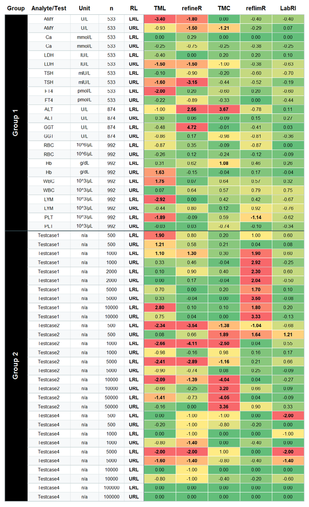

Color interpretation

D<sub>RL</sub> near 0: greater agreement

|D<sub>RL</sub>| near 1: equivalence boundary

Orange/red tones: |D<sub>RL</sub>| > 1, outside the interval; value shown in bold

## Direct ranking by inclusion within the equivalence interval

| Group | Rank | Method | Limits within EI (%) | LRLs within EI | Total LRLs | URLs within EI | Total URLs | Total within EI | Total possible |
| --- | --- | --- | --- | --- | --- | --- | --- | --- | --- |
| Group 1 | 1 | LabRI | 100.00% | 12 | 12 | 12 | 12 | 24 | 24 |
|  | 2 | reflimR | 95.83% | 11 | 12 | 12 | 12 | 23 | 24 |
|  | 3 | TMC | 87.50% | 10 | 12 | 11 | 12 | 21 | 24 |
|  | 4 | refineR | 75.00% | 9 | 12 | 9 | 12 | 18 | 24 |
|  | 5 | TML | 66.67% | 7 | 12 | 9 | 12 | 16 | 24 |
| Group 2 | 1 | LabRI | 86.67% | 13 | 15 | 13 | 15 | 26 | 30 |
|  | 2 | refineR | 73.33% | 9 | 15 | 13 | 15 | 22 | 30 |
|  | 2 | TMC | 73.33% | 10 | 15 | 12 | 15 | 22 | 30 |
|  | 4 | reflimR | 66.67% | 10 | 15 | 10 | 15 | 20 | 30 |
|  | 5 | TML | 63.33% | 6 | 15 | 13 | 15 | 19 | 30 |
| Global | 1 | LabRI | 92.59% | 25 | 27 | 25 | 27 | 50 | 54 |
|  | 2 | reflimR | 79.63% | 21 | 27 | 22 | 27 | 43 | 54 |
|  | 2 | TMC | 79.63% | 20 | 27 | 23 | 27 | 43 | 54 |
|  | 4 | refineR | 74.07% | 18 | 27 | 22 | 27 | 40 | 54 |
|  | 5 | TML | 64.81% | 13 | 27 | 22 | 27 | 35 | 54 |

Note: Percentage calculated using |D<sub>RL</sub>| ≤ 1. Tied values receive the same Rank.

## Composite PRIDE-RL ranking

| Group 1 Rank | Group 1 Method | Group 1 Idx | Group 1 N limits | Group 1 Conformity n(\|D<sub>RL</sub>\| ≤ 1) / N | Group 1 Conformity d1 | Group 1 Proximity mean(\|D<sub>RL</sub>\|) | Group 1 Proximity d2 | Group 1 Tail behaviour P90(\|D<sub>RL</sub>\|) | Group 1 Tail behaviour d3 | Group 1 Severity n(\|D<sub>RL</sub>\| > 2) | Group 1 Severity d4 | Group 1 PRIDE-RL score |  |
| --- | --- | --- | --- | --- | --- | --- | --- | --- | --- | --- | --- | --- | --- |
| 5 | TML | 1 | 24 | 16 | 0.667 | 0.97 | 0.508 | 1.97 | 0.508 | 2 | 0.706 |  | 0.663 |
| 4 | refineR | 2 | 24 | 18 | 0.750 | 0.89 | 0.529 | 2.33 | 0.429 | 3 | 0.615 | 0.741 |  |
| 3 | TMC | 3 | 24 | 21 | 0.875 | 0.56 | 0.640 | 1.05 | 0.949 | 1 | 0.828 | 0.872 |  |
| 2 | reflimR | 4 | 24 | 23 | 0.958 | 0.44 | 0.692 | 0.85 | 1.000 | 0 | 1.000 | 0.955 |  |
| 1 | LabRI | 5 | 24 | 24 | 1.000 | 0.33 | 0.750 | 0.69 | 1.000 | 0 | 1.000 | 0.996 |  |

| Group 2 Rank | Group 2 Method | Group 2 Idx | Group 2 N limits | Group 2 Conformity n(\|D<sub>RL</sub>\| ≤ 1) / N | Group 2 Conformity d1 | Group 2 Proximity mean(\|D<sub>RL</sub>\|) | Group 2 Proximity d2 | Group 2 Tail behaviour P90(\|D<sub>RL</sub>\|) | Group 2 Tail behaviour d3 | Group 2 Severity n(\|D<sub>RL</sub>\| > 2) | Group 2 Severity d4 | Group 2 PRIDE-RL score |  |
| --- | --- | --- | --- | --- | --- | --- | --- | --- | --- | --- | --- | --- | --- |
| 5 | TML | 1 | 30 | 19 | 0.633 | 0.94 | 0.514 | 2.35 | 0.426 | 5 | 0.545 |  | 0.629 |
| 2 | refineR | 2 | 30 | 22 | 0.733 | 0.96 | 0.511 | 2.09 | 0.479 | 3 | 0.667 | 0.727 |  |
| 3 | TMC | 3 | 30 | 22 | 0.733 | 0.94 | 0.516 | 3.21 | 0.311 | 5 | 0.545 | 0.724 |  |
| 4 | reflimR | 4 | 30 | 20 | 0.667 | 0.89 | 0.529 | 2.36 | 0.423 | 5 | 0.545 | 0.661 |  |
| 1 | LabRI | 5 | 30 | 26 | 0.867 | 0.48 | 0.677 | 1.23 | 0.812 | 0 | 1.000 | 0.865 |  |

| Global: all reference limits (Group 1 + Group 2) Rank | Global: all reference limits (Group 1 + Group 2) Method | Global: all reference limits (Group 1 + Group 2) Idx | Global: all reference limits (Group 1 + Group 2) N limits | Global: all reference limits (Group 1 + Group 2) Conformity n(\|D<sub>RL</sub>\| ≤ 1) / N | Global: all reference limits (Group 1 + Group 2) Conformity d1 | Global: all reference limits (Group 1 + Group 2) Proximity mean(\|D<sub>RL</sub>\|) | Global: all reference limits (Group 1 + Group 2) Proximity d2 | Global: all reference limits (Group 1 + Group 2) Tail behaviour P90(\|D<sub>RL</sub>\|) | Global: all reference limits (Group 1 + Group 2) Tail behaviour d3 | Global: all reference limits (Group 1 + Group 2) Severity n(\|D<sub>RL</sub>\| > 2) | Global: all reference limits (Group 1 + Group 2) Severity d4 | Global: all reference limits (Group 1 + Group 2) PRIDE-RL score |  |
| --- | --- | --- | --- | --- | --- | --- | --- | --- | --- | --- | --- | --- | --- |
| 5 | TML | 1 | 54 | 35 | 0.648 | 0.95 | 0.512 | 2.26 | 0.442 | 7 | 0.607 |  | 0.646 |
| 4 | refineR | 2 | 54 | 40 | 0.741 | 0.93 | 0.519 | 2.39 | 0.419 | 6 | 0.643 | 0.737 |  |
| 3 | TMC | 3 | 54 | 43 | 0.796 | 0.77 | 0.565 | 2.32 | 0.432 | 6 | 0.643 | 0.792 |  |
| 2 | reflimR | 4 | 54 | 43 | 0.796 | 0.69 | 0.591 | 1.87 | 0.535 | 5 | 0.684 | 0.793 |  |
| 1 | LabRI | 5 | 54 | 50 | 0.926 | 0.41 | 0.708 | 0.76 | 1.000 | 0 | 1.000 | 0.925 |  |

| Ordered ranking Pos. | Ordered ranking Group 1 Rank | Ordered ranking Group 1 Method | Ordered ranking Group 1 PRIDE-RL score | Ordered ranking Group 2 Rank | Ordered ranking Group 2 Method | Ordered ranking Group 2 PRIDE-RL score | Ordered ranking Global Rank | Ordered ranking Global Method | Ordered ranking Global PRIDE-RL score |
| --- | --- | --- | --- | --- | --- | --- | --- | --- | --- |
| 1 | 1 | LabRI | 0.996 | 1 | LabRI | 0.865 | 1 | LabRI | 0.925 |
| 2 | 2 | reflimR | 0.955 | 2 | refineR | 0.727 | 2 | reflimR | 0.793 |
| 3 | 3 | TMC | 0.872 | 3 | TMC | 0.724 | 3 | TMC | 0.792 |
| 4 | 4 | refineR | 0.741 | 4 | reflimR | 0.661 | 4 | refineR | 0.737 |
| 5 | 5 | TML | 0.663 | 5 | TML | 0.629 | 5 | TML | 0.646 |

Note: d1–d4 are the normalized dimensions. The conformity-prioritized PRIDe-RL score is [N<sub>i</sub> × d<sub>1</sub> + (d2 × d3 × d4)<sup>1/3</sup>] / (N<sub>i</sub> + 1), where N<sub>i</sub> is the number of evaluated limits for method i and d<sub>1</sub> is the proportion with |D<sub>RL</sub>| ≤ 1. The geometric mean of d2–d4 provides the fractional secondary component; the color changes from yellow to green as the score increases.

## Parameters and equivalence intervals

| Grupo | Row | Analyte | n | Unit | Decimal places | Comparative LRL | Comparative URL | CVE | pCVA | Medln | Median pSDA | Slope | Intercept | pSDA LRL | pD LRL | Lower LRL EI | Upper LRL EI | pSDA URL | pD URL | Lower URL EI | Upper URL EI | LRL equivalence interval | URL equivalence interval |
| --- | --- | --- | --- | --- | --- | --- | --- | --- | --- | --- | --- | --- | --- | --- | --- | --- | --- | --- | --- | --- | --- | --- | --- |
| Group 1 | 1 | AMY | 533 | U/L | 0 | 47.000000 | 164.000000 | 0.327081 | 0.056972 | 87.795216 | 5.001867 | 0.045578 | 1.000373 | 3.142520 | 5.168985 | 42.000000 | 52.000000 | 8.475097 | 13.940294 | 150.000000 | 178.000000 | 42 to 52 | 150 to 178 |
|  | 2 | Ca | 533 | mmol/L | 2 | 2.190000 | 2.570000 | 0.040834 | 0.019579 | 2.372404 | 0.046450 | 0.015663 | 0.009290 | 0.043593 | 0.071704 | 2.120000 | 2.260000 | 0.049545 | 0.081494 | 2.490000 | 2.650000 | 2.12 to 2.26 | 2.49 to 2.65 |
|  | 3 | LDH | 533 | IU/L | 0 | 138.000000 | 257.000000 | 0.159631 | 0.039640 | 188.324189 | 7.465131 | 0.031712 | 1.493026 | 5.869259 | 9.654072 | 128.000000 | 148.000000 | 9.642967 | 15.861270 | 241.000000 | 273.000000 | 128 to 148 | 241 to 273 |
|  | 4 | TSH | 533 | mIU/L | 2 | 0.610000 | 4.860000 | 0.568780 | 0.075252 | 1.721801 | 0.129568 | 0.060201 | 0.025914 | 0.062636 | 0.103028 | 0.510000 | 0.710000 | 0.318492 | 0.523872 | 4.340000 | 5.380000 | 0.51 to 0.71 | 4.34 to 5.38 |
|  | 5 | FT4 | 533 | pmol/L | 1 | 7.800000 | 14.100000 | 0.151899 | 0.038652 | 10.487135 | 0.405350 | 0.030922 | 0.081070 | 0.322259 | 0.530070 | 7.300000 | 8.300000 | 0.517066 | 0.850498 | 13.200000 | 15.000000 | 7.3 to 8.3 | 13.2 to 15.0 |
|  | 6 | ALT | 874 | U/L | 1 | 6.600000 | 34.500000 | 0.441402 | 0.066250 | 15.089732 | 0.999690 | 0.053000 | 0.199938 | 0.549736 | 0.904236 | 5.700000 | 7.500000 | 2.028429 | 3.336468 | 31.200000 | 37.800000 | 5.7 to 7.5 | 31.2 to 37.8 |
|  | 7 | GGT | 874 | U/L | 2 | 12.220000 | 51.710000 | 0.380823 | 0.061508 | 25.137546 | 1.546159 | 0.049206 | 0.309232 | 0.910533 | 1.497694 | 10.720000 | 13.720000 | 2.853692 | 4.693906 | 47.020000 | 56.400000 | 10.72 to 13.72 | 47.02 to 56.40 |
|  | 8 | RBC | 992 | 10^6/μL | 2 | 3.970000 | 6.280000 | 0.117392 | 0.033896 | 4.993155 | 0.169247 | 0.027117 | 0.033849 | 0.141502 | 0.232751 | 3.740000 | 4.200000 | 0.204142 | 0.335783 | 5.940000 | 6.620000 | 3.74 to 4.20 | 5.94 to 6.62 |
|  | 9 | Hb | 992 | g/dL | 2 | 10.600000 | 17.340000 | 0.126048 | 0.035149 | 13.557433 | 0.476535 | 0.028120 | 0.095307 | 0.393374 | 0.647042 | 9.950000 | 11.250000 | 0.582899 | 0.958784 | 16.380000 | 18.300000 | 9.95 to 11.25 | 16.38 to 18.30 |
|  | 10 | WBC | 992 | 10^3/μL | 2 | 3.160000 | 7.730000 | 0.231201 | 0.047823 | 4.942348 | 0.236357 | 0.038258 | 0.047271 | 0.168167 | 0.276610 | 2.880000 | 3.440000 | 0.343007 | 0.564197 | 7.170000 | 8.290000 | 2.88 to 3.44 | 7.17 to 8.29 |
|  | 11 | LYM | 992 | 10^3/μL | 2 | 1.310000 | 3.380000 | 0.245376 | 0.049282 | 2.104234 | 0.103702 | 0.039426 | 0.020740 | 0.072388 | 0.119068 | 1.190000 | 1.430000 | 0.154000 | 0.253308 | 3.130000 | 3.630000 | 1.19 to 1.43 | 3.13 to 3.63 |
|  | 12 | PLT | 992 | 10^3/μL | 1 | 140.200000 | 384.000000 | 0.261338 | 0.050876 | 232.027585 | 11.804668 | 0.040701 | 2.360934 | 8.067201 | 13.269365 | 126.900000 | 153.500000 | 17.990084 | 29.591054 | 354.400000 | 413.600000 | 126.9 to 153.5 | 354.4 to 413.6 |
| Group 2 | 1 | Testcase1 | 500 | n/a | 1 | 10.200000 | 29.800000 | 0.278695 | 0.052554 | 17.434449 | 0.916255 | 0.042043 | 0.183251 | 0.612094 | 1.006805 | 9.200000 | 11.200000 | 1.436145 | 2.362249 | 27.400000 | 32.200000 | 9.2 to 11.2 | 27.4 to 32.2 |
|  | 2 | Testcase1 | 1000 | n/a | 1 | 10.200000 | 29.800000 | 0.278695 | 0.052554 | 17.434449 | 0.916255 | 0.042043 | 0.183251 | 0.612094 | 1.006805 | 9.200000 | 11.200000 | 1.436145 | 2.362249 | 27.400000 | 32.200000 | 9.2 to 11.2 | 27.4 to 32.2 |
|  | 3 | Testcase1 | 2000 | n/a | 1 | 10.200000 | 29.800000 | 0.278695 | 0.052554 | 17.434449 | 0.916255 | 0.042043 | 0.183251 | 0.612094 | 1.006805 | 9.200000 | 11.200000 | 1.436145 | 2.362249 | 27.400000 | 32.200000 | 9.2 to 11.2 | 27.4 to 32.2 |
|  | 4 | Testcase1 | 5000 | n/a | 1 | 10.200000 | 29.800000 | 0.278695 | 0.052554 | 17.434449 | 0.916255 | 0.042043 | 0.183251 | 0.612094 | 1.006805 | 9.200000 | 11.200000 | 1.436145 | 2.362249 | 27.400000 | 32.200000 | 9.2 to 11.2 | 27.4 to 32.2 |
|  | 5 | Testcase1 | 10000 | n/a | 1 | 10.200000 | 29.800000 | 0.278695 | 0.052554 | 17.434449 | 0.916255 | 0.042043 | 0.183251 | 0.612094 | 1.006805 | 9.200000 | 11.200000 | 1.436145 | 2.362249 | 27.400000 | 32.200000 | 9.2 to 11.2 | 27.4 to 32.2 |
|  | 6 | Testcase2 | 500 | n/a | 1 | 59.800000 | 160.000000 | 0.255072 | 0.050257 | 97.816154 | 4.915902 | 0.040205 | 0.983180 | 3.387454 | 5.571865 | 54.200000 | 65.400000 | 7.416019 | 12.198265 | 147.800000 | 172.200000 | 54.2 to 65.4 | 147.8 to 172.2 |
|  | 7 | Testcase2 | 1000 | n/a | 1 | 59.800000 | 160.000000 | 0.255072 | 0.050257 | 97.816154 | 4.915902 | 0.040205 | 0.983180 | 3.387454 | 5.571865 | 54.200000 | 65.400000 | 7.416019 | 12.198265 | 147.800000 | 172.200000 | 54.2 to 65.4 | 147.8 to 172.2 |
|  | 8 | Testcase2 | 5000 | n/a | 1 | 59.800000 | 160.000000 | 0.255072 | 0.050257 | 97.816154 | 4.915902 | 0.040205 | 0.983180 | 3.387454 | 5.571865 | 54.200000 | 65.400000 | 7.416019 | 12.198265 | 147.800000 | 172.200000 | 54.2 to 65.4 | 147.8 to 172.2 |
|  | 9 | Testcase2 | 10000 | n/a | 1 | 59.800000 | 160.000000 | 0.255072 | 0.050257 | 97.816154 | 4.915902 | 0.040205 | 0.983180 | 3.387454 | 5.571865 | 54.200000 | 65.400000 | 7.416019 | 12.198265 | 147.800000 | 172.200000 | 54.2 to 65.4 | 147.8 to 172.2 |
|  | 10 | Testcase2 | 50000 | n/a | 1 | 59.800000 | 160.000000 | 0.255072 | 0.050257 | 97.816154 | 4.915902 | 0.040205 | 0.983180 | 3.387454 | 5.571865 | 54.200000 | 65.400000 | 7.416019 | 12.198265 | 147.800000 | 172.200000 | 54.2 to 65.4 | 147.8 to 172.2 |
|  | 11 | Testcase4 | 500 | n/a | 0 | 10.000000 | 50.000000 | 0.428497 | 0.065268 | 22.360680 | 1.459446 | 0.052215 | 0.291889 | 0.814036 | 1.338971 | 9.000000 | 11.000000 | 2.902626 | 4.774394 | 45.000000 | 55.000000 | 9 to 11 | 45 to 55 |
|  | 12 | Testcase4 | 1000 | n/a | 0 | 10.000000 | 50.000000 | 0.428497 | 0.065268 | 22.360680 | 1.459446 | 0.052215 | 0.291889 | 0.814036 | 1.338971 | 9.000000 | 11.000000 | 2.902626 | 4.774394 | 45.000000 | 55.000000 | 9 to 11 | 45 to 55 |
|  | 13 | Testcase4 | 5000 | n/a | 0 | 10.000000 | 50.000000 | 0.428497 | 0.065268 | 22.360680 | 1.459446 | 0.052215 | 0.291889 | 0.814036 | 1.338971 | 9.000000 | 11.000000 | 2.902626 | 4.774394 | 45.000000 | 55.000000 | 9 to 11 | 45 to 55 |
|  | 14 | Testcase4 | 10000 | n/a | 0 | 10.000000 | 50.000000 | 0.428497 | 0.065268 | 22.360680 | 1.459446 | 0.052215 | 0.291889 | 0.814036 | 1.338971 | 9.000000 | 11.000000 | 2.902626 | 4.774394 | 45.000000 | 55.000000 | 9 to 11 | 45 to 55 |
|  | 15 | Testcase4 | 100000 | n/a | 0 | 10.000000 | 50.000000 | 0.428497 | 0.065268 | 22.360680 | 1.459446 | 0.052215 | 0.291889 | 0.814036 | 1.338971 | 9.000000 | 11.000000 | 2.902626 | 4.774394 | 45.000000 | 55.000000 | 9 to 11 | 45 to 55 |

Note: Parameters calculated separately for the LRL and URL of each analyte.

## Detailed method assessment

| Grupo | Row | Analyte | n | Unit | Method | Estimated LRL | D<sub>RL</sub> LRL | LRL within EI | Estimated URL | D<sub>RL</sub> URL | URL within EI |
| --- | --- | --- | --- | --- | --- | --- | --- | --- | --- | --- | --- |
| Group 1 | 1 | AMY | 533 | U/L | TML | 29.50000 | -3.40000 | 0 | 151.00000 | -0.92857 | 1 |
|  | 1 | AMY | 533 | U/L | refineR | 37.80000 | -1.80000 | 0 | 143.00000 | -1.50000 | 0 |
|  | 1 | AMY | 533 | U/L | TMC | 47.40000 | 0.00000 | 1 | 147.00000 | -1.21429 | 0 |
|  | 1 | AMY | 533 | U/L | reflimR | 45.30000 | -0.40000 | 1 | 160.20000 | -0.28571 | 1 |
|  | 1 | AMY | 533 | U/L | LabRI | 45.00000 | -0.40000 | 1 | 165.00000 | 0.07143 | 1 |
|  | 2 | Ca | 533 | mmol/L | TML | 2.19000 | 0.00000 | 1 | 2.55000 | -0.25000 | 1 |
|  | 2 | Ca | 533 | mmol/L | refineR | 2.21000 | 0.28571 | 1 | 2.51000 | -0.75000 | 1 |
|  | 2 | Ca | 533 | mmol/L | TMC | 2.19000 | 0.00000 | 1 | 2.55000 | -0.25000 | 1 |
|  | 2 | Ca | 533 | mmol/L | reflimR | 2.19000 | 0.00000 | 1 | 2.54000 | -0.37500 | 1 |
|  | 2 | Ca | 533 | mmol/L | LabRI | 2.19000 | 0.00000 | 1 | 2.55000 | -0.25000 | 1 |
|  | 3 | LDH | 533 | IU/L | TML | 134.00000 | -0.40000 | 1 | 233.00000 | -1.50000 | 0 |
|  | 3 | LDH | 533 | IU/L | refineR | 138.00000 | 0.00000 | 1 | 233.00000 | -1.50000 | 0 |
|  | 3 | LDH | 533 | IU/L | TMC | 140.00000 | 0.20000 | 1 | 241.00000 | -1.00000 | 1 |
|  | 3 | LDH | 533 | IU/L | reflimR | 140.00000 | 0.20000 | 1 | 251.00000 | -0.37500 | 1 |
|  | 3 | LDH | 533 | IU/L | LabRI | 139.00000 | 0.10000 | 1 | 247.00000 | -0.62500 | 1 |
|  | 4 | TSH | 533 | mIU/L | TML | 0.60000 | -0.10000 | 1 | 4.03000 | -1.59615 | 0 |
|  | 4 | TSH | 533 | mIU/L | refineR | 0.52000 | -0.90000 | 1 | 3.22000 | -3.15385 | 0 |
|  | 4 | TSH | 533 | mIU/L | TMC | 0.59000 | -0.20000 | 1 | 4.63000 | -0.44231 | 1 |
|  | 4 | TSH | 533 | mIU/L | reflimR | 0.55000 | -0.60000 | 1 | 4.59000 | -0.51923 | 1 |
|  | 4 | TSH | 533 | mIU/L | LabRI | 0.54000 | -0.70000 | 1 | 4.76000 | -0.19231 | 1 |
|  | 5 | FT4 | 533 | pmol/L | TML | 6.76000 | -2.00000 | 0 | 13.90000 | -0.22222 | 1 |
|  | 5 | FT4 | 533 | pmol/L | refineR | 7.92000 | 0.20000 | 1 | 13.30000 | -0.88889 | 1 |
|  | 5 | FT4 | 533 | pmol/L | TMC | 7.54000 | -0.60000 | 1 | 13.80000 | -0.33333 | 1 |
|  | 5 | FT4 | 533 | pmol/L | reflimR | 7.90000 | 0.20000 | 1 | 14.10000 | 0.00000 | 1 |
|  | 5 | FT4 | 533 | pmol/L | LabRI | 7.50000 | -0.60000 | 1 | 13.70000 | -0.44444 | 1 |
|  | 6 | ALT | 874 | U/L | TML | 5.70000 | -1.00000 | 1 | 35.50000 | 0.30303 | 1 |
|  | 6 | ALT | 874 | U/L | refineR | 8.87000 | 2.55556 | 0 | 34.70000 | 0.06061 | 1 |
|  | 6 | ALT | 874 | U/L | TMC | 9.94000 | 3.66667 | 0 | 34.20000 | -0.09091 | 1 |
|  | 6 | ALT | 874 | U/L | reflimR | 5.90000 | -0.77778 | 1 | 35.00000 | 0.15152 | 1 |
|  | 6 | ALT | 874 | U/L | LabRI | 6.70000 | 0.11111 | 1 | 35.40000 | 0.27273 | 1 |

[output cut: 105 more lines]

Note: D<sub>RL</sub> uses the rounded method estimate and the distance from the comparative RL to the rounded EI boundary on the corresponding side. Excel-compatible rounding uses the decimal places of each row (default: 3); |D<sub>RL</sub>| ≤ 1 indicates inclusion within the EI.

## PRIDe-RL scoring framework

Calculation workflow, variable definitions, scoring dimensions, and the conformity-prioritized PRIDe-RL score used to rank reference-limit estimation methods.

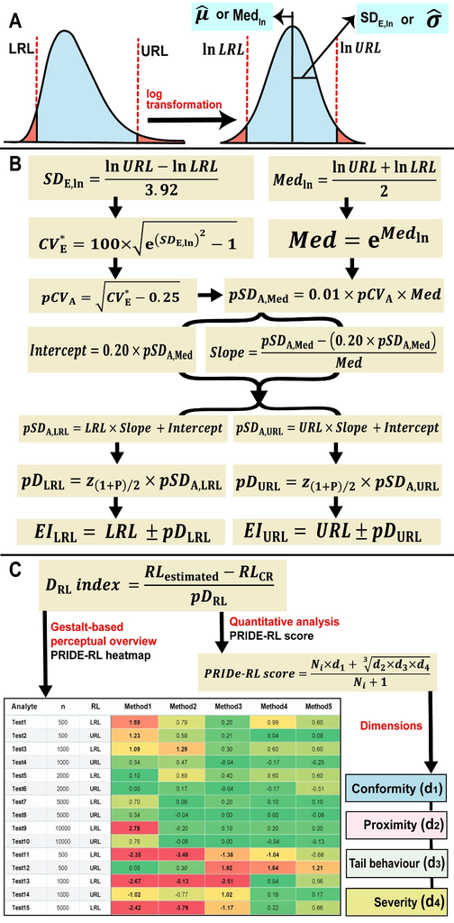

Overview of the PRIDe-RL calculation workflow. The coverage factor is represented by the standard-normal quantile *z* at probability (1 + *P*) / 2, where *P* is the nominal central coverage selected by the user. The equations for the four scoring dimensions are detailed below.

Abbreviations and definitions:

LRL, lower reference limit.

URL, upper reference limit.

CV<sub>E</sub>*, empirical biological variation coefficient derived on the logarithmic scale from the reference interval. If the LRL is unknown, it is set at 15% of the URL for the CVE calculation.

pCV<sub>A</sub>, permissible analytical coefficient of variation (CVA) at the median on the linear scale, obtained from the CVE.

Med<sub>ln</sub>, median of the reference interval on the logarithmic scale.

pSD<sub>A,Med</sub>, permissible analytical standard deviation (SDA) at the median of the reference interval.

Slope, calculated from pSDA,Med and the median of the reference interval.

Intercept, related to the limit of detection. Because the limit of detection is usually unknown for the human material matrix, 20% of pSDA,Med is applied empirically here as a surrogate.

pSD<sub>A,LRL</sub>, permissible analytical standard deviation at the lower reference limit.

pSD<sub>A,URL</sub>, permissible analytical standard deviation at the upper reference limit.

pD<sub>LRL</sub>, permissible difference (pD) for the LRL, based on Haeckel's approach, which estimates the CVE from the reference interval provided by the user.

pD<sub>URL</sub>, permissible difference (pD) for the URL, based on Haeckel's approach, which estimates the CVE from the reference interval provided by the user.

EI, equivalence interval, the range around a reference limit within which an estimate of that same limit obtained by another approach is considered equivalent.

EI<sub>LRL</sub>, equivalence interval of the lower reference limit (LRL ± pDLRL).

EI<sub>URL</sub>, equivalence interval of the upper reference limit (URL ± pDURL).

RL, reference limit, either the lower (LRL) or the upper (URL) reference limit.

D<sub>RL</sub> index, signed deviation of the rounded method estimate from its comparative reference limit, divided by the distance to the rounded EI boundary on the corresponding side. Excel-compatible rounding uses the decimal places of each row (default: 3). D-RL = 0 denotes agreement; |D-RL| ≤ 1 denotes inclusion within the EI, and the sign indicates the direction of deviation.

PRIDe-RL score, conformity-prioritized composite measure defined as [Ni × d1 + (d2 × d3 × d4)^(1/3)] / (Ni + 1), where Ni is the number of evaluated reference limits for method i and d1 is their conforming proportion. The product Ni × d1 equals the integer conformity count in the numerator, whereas the geometric mean of proximity, tail behaviour, and severity is its fractional secondary component; higher values indicate better performance.

- **Direct ranking**

  Proportion of LRLs and URLs within their respective equivalence intervals.
- **d1 — Conformity**

  $$d1=n(|DRL|≤1)N$$

  Where:

  n(|D<sub>RL</sub>| ≤ 1), number of evaluated reference-limit estimates (LRLs and URLs) whose absolute deviation index is less than or equal to 1, indicating inclusion within the equivalence interval.

  N, total number of evaluated reference-limit estimates with an available D-RL value for the method within the corresponding assessment scope (group or global).
- **d2 — Proximity**

  $$d2=11+mean(|DRL|)$$

  Where:

  mean(|D<sub>RL</sub>|), arithmetic mean of the absolute D-RL values across all available LRL and URL estimates for the method within the corresponding assessment scope.

  |D<sub>RL</sub>|, absolute reference limit deviation index, expressing the magnitude of the deviation from the comparative reference limit irrespective of direction.
- **d3 — Tail behaviour**

  $$d3=11+max[0,P90(|DRL|)−1]$$

  Where:

  P<sub>90</sub>(|D<sub>RL</sub>|), inclusive 90th percentile of the absolute D-RL values across the available LRL and URL estimates for the method within the corresponding assessment scope.

  max[0, P<sub>90</sub>(|D<sub>RL</sub>|) − 1], non-negative tail excess beyond the equivalence boundary; it equals zero when the 90th percentile is less than or equal to 1.
- **d4 — Severity**

  $$d4=11+5×n(|DRL|>2)N$$

  Where:

  n(|D<sub>RL</sub>| > 2), number of evaluated reference-limit estimates (LRLs and URLs) whose absolute deviation index is greater than 2.

  N, total number of evaluated reference-limit estimates with an available D-RL value for the method within the corresponding assessment scope (group or global).

  2, severity threshold corresponding to a deviation greater than twice the permissible difference (pD).

  5, fixed multiplier that controls the strength of the penalty for severe deviations.
- **PRIDe-RL score**

  $$PRIDe-RL score=Ni×d1+d2×d3×d43Ni+1$$

  Where:

  d<sub>1</sub>, conformity: proportion of evaluated reference limits for method i with |D-RL| less than or equal to 1. Thus, Ni × d1 equals the integer number of conforming limits.

  (d2 × d3 × d4)<sup>1/3</sup>, geometric mean of the secondary dimensions, ranging from 0 to 1 and used as the fractional component of the score.

  N<sub>i</sub>, total number of evaluated reference limits with an available D-RL value for method i within the corresponding assessment scope (group or global).

## Methodological references

1. R. Haeckel, T. Ammer, W. Wosniok, A. Krebs, A. Torge, M. Özcürümez, A. Bertram, Age-and sex-specific reference intervals of total cholesterol, LDL cholesterol, HDL cholesterol and non-HDL cholesterol. Comparison of two algorithms for the indirect estimation of reference intervals, *Journal of Laboratory Medicine* 47 (2023) 55–62. https://doi.org/10.1515/labmed-2022-0147
2. R. Haeckel, K. Adeli, G. Jones, K. Sikaris, W. Wosniok, Definitions and major prerequisites of direct and indirect approaches for estimating reference limits, *Clinical Chemistry and Laboratory Medicine (CCLM)* 61 (2023) 402–406. https://doi.org/10.1515/cclm-2022-1061
3. R. Haeckel, W. Wosniok, T. Streichert, Review of potentials and limitations of indirect approaches for estimating reference limits/intervals of quantitative procedures in laboratory medicine, *Journal of Laboratory Medicine* 45 (2021) 35–53. https://doi.org/10.1515/labmed-2020-0131
4. E. Gurr, R. Haeckel, M. Orth, T. Streichert, Festlegung der zulässigen Messunsicherheit quantitativer Messgrößen in der Laboratoriumsmedizin, *LaboratoriumsMedizin* 41 (2017) 53–58. https://doi.org/10.1515/labmed-2016-0079
5. R. Haeckel, W. Wosniok, F. Arzideh, Equivalence limits of reference intervals for partitioning of population data. Relevant differences of reference limits, *LaboratoriumsMedizin* 40 (2016) 199–205. https://doi.org/10.1515/labmed-2016-0002
6. R. Haeckel, E. Gurr, T. Keller, Permissible measurement uncertainty in the lower part of measurement intervals, *LaboratoriumsMedizin* 40 (2016) 271–276. https://doi.org/10.1515/labmed-2016-0006
7. R. Haeckel, W. Wosniok, E. Gurr, B. Peil, Permissible limits for uncertainty of measurement in laboratory medicine, *Clinical Chemistry and Laboratory Medicine (CCLM)* 53 (2015). https://doi.org/10.1515/cclm-2014-0874
8. R. Haeckel, W. Wosniok, T. Streichert, Optimizing the use of the “state-of-the-art” performance criteria, *Clinical Chemistry and Laboratory Medicine (CCLM)* 53 (2015). https://doi.org/10.1515/cclm-2014-1201
9. R. Haeckel, W. Wosniok, J. Kratochvila, A. Carobene, A pragmatic proposal for permissible limits in external quality assessment schemes with a compromise between biological variation and the state of the art, *Clinical Chemistry and Laboratory Medicine* 50 (2012). https://doi.org/10.1515/cclm-2011-0862
10. E. Colet, D. Aaronson, Visualization of multivariate data: Human-factors considerations, *Behavior Research Methods, Instruments, & Computers* 27 (1995) 257–263. https://doi.org/10.3758/BF03204742
11. S. Engle, S. Whalen, A. Joshi, K.S. Pollard, Unboxing cluster heatmaps, *BMC Bioinformatics* 18 (2017) 63. https://doi.org/10.1186/s12859-016-1442-6
12. T. Ammer, A. Schützenmeister, H.-U. Prokosch, J. Zierk, C.M. Rank, M. Rauh, RIbench: A Proposed Benchmark for the Standardized Evaluation of Indirect Methods for Reference Interval Estimation, *Clinical Chemistry* 68 (2022) 1410–1424. https://doi.org/10.1093/clinchem/hvac142
13. L.M. Weber, W. Saelens, R. Cannoodt, C. Soneson, A. Hapfelmeier, P.P. Gardner, A.-L. Boulesteix, Y. Saeys, M.D. Robinson, Essential guidelines for computational method benchmarking, *Genome Biol* 20 (2019) 125. https://doi.org/10.1186/s13059-019-1738-8
14. J. Smolander, S. Junttila, L.L. Elo, Cell-connectivity-guided trajectory inference from single-cell data, *Bioinformatics* 39 (2023) btad515. https://doi.org/10.1093/bioinformatics/btad515

Original PRIDE-RL tool: Alan Carvalho Dias. ORCID: 0000-0002-7159-4593.

Intended for research and laboratory quality assurance; not intended for individual diagnostic decisions.